# The Perception Gap: What Each Party Thinks the Other Looks Like

Everyone guesses forty

Democracy’s Data

Last updated September 13, 2026 at 10:53a EDT

Each party is said to caricature the other. Democrats are pictured as a party of activists and minorities, Republicans as a party of the old and the rich, and commentators repeat that the two sides no longer see each other clearly. Is that true — and if it is, by how much, and about what?

One number suggests the size of the problem. Out of every hundred Republicans, how many earn more than $250,000 a year? The average American answer is **38.2**. The real figure is **2.2**. That is the most quoted result from a study of what people believe the two parties are made of, and it is one of eight. The distance between the real figure and the guessed one is the **perception gap** of the title.

## The test

In March 2015 [YouGov](https://today.yougov.com/), a polling firm that surveys people online, put eight questions to 1,000 Americans. For each party it named four groups that party is stereotyped around, and asked what percentage of that party’s supporters belong to each. Four Democratic groups, four Republican ones, 8,000 answers in all. The study was run for two political scientists, Douglas Ahler and Gaurav Sood, who published it in 2018.[^1] The copy read here is their replication deposit — the data they filed so that other researchers could check their results — on [Harvard Dataverse](https://doi.org/10.7910/DVN/CLMQ8E), a public archive run by Harvard University, where anyone can download it without an account.

Most opinion measures can never be graded. A poll about a vote is eventually scored against a real election; a question about trust or ideology never is, which is the standing problem of the Public Opinion cluster’s data chapter. These eight questions are the rare exception. Each asks for a number that other surveys measure — the true share of each party belonging to each group. The authors computed those shares from three sources that ask about party as well as about the group in question: the American National Election Studies, the long-running academic survey of American voters; the [Current Population Survey](https://www.census.gov/programs-surveys/cps.html), the Census Bureau’s monthly survey of households; and a Pew Research Center report on religion, its [Religious Landscape Study](https://www.pewresearch.org/religion/religious-landscape-study/). A guess with a right answer beside it can be graded, and that is the whole design.

Because the file also records each respondent’s own party, the same grading can be run twice: once on what people say about their own side, and once on what they say about the other one. That second comparison is the study’s actual argument, and the famous figure cannot show it.

## The data

Everything below comes from a file of 26 columns: one row per respondent, with the eight estimates, a case weight, and the respondent’s own party identification in `pid7`, the seven-point scale that runs from strong Democrat to strong Republican. The weight is YouGov’s answer to a known problem: the panel is people who volunteer to take surveys online, and volunteers are not a random draw of the country. Weighting means counting some answers more than others, so that the mix of ages, races, educations and so on among the volunteers matches the country’s, with the targets taken from the census.

The tables the figures rest on were rebuilt from that file. `items.csv` holds the eight groups with the true share (`actual_pct`), the average guess (`perceived_pct`), the middle guess (`median`), and the gap measured both ways. `by_party.csv` splits every guess by who was answering. `dist.csv` counts how many people gave each value from 0 to 100, and `heaping.csv` counts how round the answers are. The averages here were recomputed from the 8,000 individual answers rather than copied from the paper; they match the published ones to five decimal places.

One cleaning decision matters enough to name. People who call themselves independent and then admit to leaning toward a party are counted as partisans, which is the party-id chapter’s subject. The cost of that choice is measured below.

The file is a copy of part of the study, not the study. The deposit ships its own codebook — the document listing what each column holds — so the two can be set against each other:

| Column | Which side it falls on |
| --- | --- |
| pew_churatd | described, and not in the file |
| pew_prayer | described, and not in the file |
| pew_religimp | described, and not in the file |
| ideo5 | in the file, and not described |
| newsint | in the file, and not described |
| newsint_r | in the file, and not described |
| pid3 | in the file, and not described |
| pid7 | in the file, and not described |
| votereg | in the file, and not described |

3 columns are described in the codebook and are not in the file. 6 are in the file and are not in the codebook, and one of those is `pid7`, the column half of this brief rests on. The questionnaire as administered, the panel the thousand were drawn from, everyone who started and gave up — none of that is anywhere a reader can go. When a finding rests on a public file, ask what was collected, then ask what was deposited, and do not assume the second is the first with fewer rows.

> **Before you read on, commit to two numbers.** First: for the average group, by how many points do you expect the average guess to miss the true share? Second: of the 8,000 answers in the file, what share do you expect to be round numbers ending in a zero? Write both down. A guess you have not written down is one you will quietly revise.

## What it says about democracy

| Party | Out of every 100 supporters, how many are… | Really | People said | Gap |
| --- | --- | --- | --- | --- |
| Democratic | Union member | 10.5% | 39.3% | +28.8 |
| Democratic | Lesbian, gay or bisexual | 6.3% | 31.7% | +25.4 |
| Democratic | Atheist or agnostic | 8.7% | 28.7% | +20.0 |
| Democratic | Black | 24.0% | 41.9% | +17.9 |
| Republican | Earning $250K+ | 2.2% | 38.2% | +36.1 |
| Republican | Aged 65 or over | 21.3% | 39.1% | +17.8 |
| Republican | Evangelical | 34.3% | 41.6% | +7.3 |
| Republican | Southern | 35.6% | 40.4% | +4.7 |

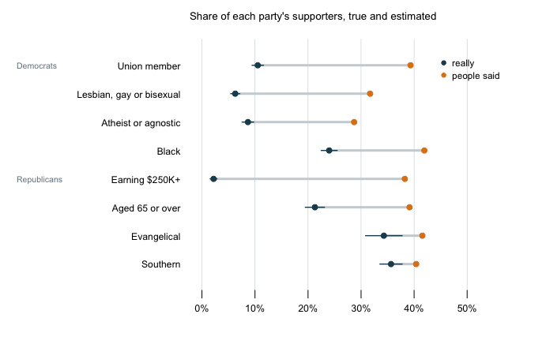

Hover a row for the pair and the gap. The short bar through the dark dot is the interval on the true share, which is itself a survey estimate.

**Figure 1. The eight items: the true share of each group, and what people said.** Each row is one question, drawn as a pair of dots joined by a bar, because the finding is a distance — the gap between what a party is and what people think it is. The dark dot is the true share, the light dot is the average guess.

Every single group is overestimated, and the average gap is **19.8 points**. The sizes are not alike: earning $250K+ is out by 36.1 points, Southern by 4.7. The pattern in those sizes is worth having first: the groups people are most wrong about are the rarest ones. Lesbian, gay or bisexual Democrats are 6.3% of their party and people said 31.7%, while Southerners really are 35.6% of Republicans and the guess was close.

The split by who was answering is where the claim about the parties gets its answer.

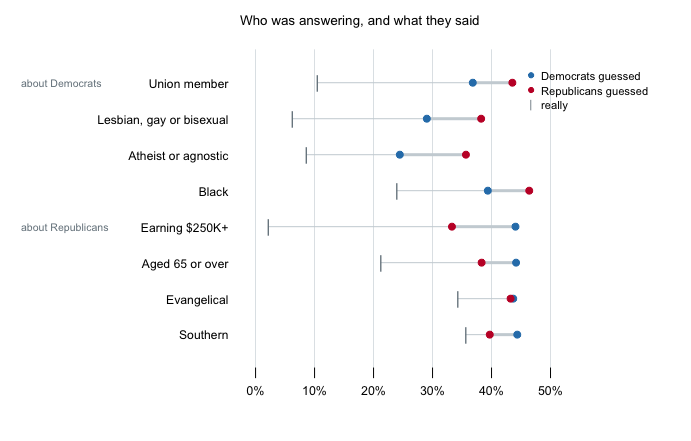

Hover a row for all three numbers. The top four rows are groups of Democrats and the bottom four are groups of Republicans, so the far dot changes colour halfway down.

**Figure 2. The same eight items, split by who answered.** The blue dot is what Democratic respondents said, the red dot what Republican respondents said, and the grey tick is the truth. The top four rows ask about groups of Democrats, the bottom four about groups of Republicans — so the far dot changes colour halfway down, and that is the finding.

| Who was answering | Asked about | Average overestimate (pts) |
| --- | --- | --- |
| Democrats | their own party | +20.1 |
| Republicans | their own party | +15.3 |
| Democrats | the other party | +20.7 |
| Republicans | the other party | +28.6 |

Follow one question through. *Out of every 100 Republicans, how many are earning over $250,000 a year?* The true answer, as the authors computed it from other surveys, is 2.2. Republicans, asked about their own party, said 33.3 on average — 31.1 points too high. Democrats, asked about the other side, said 44.1 — 41.9 points too high. Both sides overshoot, and the side that is not in the party overshoots further. The table above is that comparison averaged over all eight questions.

Asked about their own party, people overestimate by **17.7 points**. Asked about the other one, by **24.6**. Both sides do it, and in the same direction. The worst single cell in the study is Democrats estimating how many Republicans are earning over $250,000 a year: out by 41.9 points. Counting leaners as partisans is a decision here; push them back out and the two numbers become 17.3 and 23.3 — smaller, same direction, same conclusion.

This is the sense in which polarization runs partly on wrong facts. You cannot meet a political party. You learn what is in the other one from people describing it to you, and the picture assembled from the descriptions puts the other side’s most stereotyped groups at several times their real size.

The average guess itself deserves a look, because each point in Figure 1 is a thousand people reduced to one number.

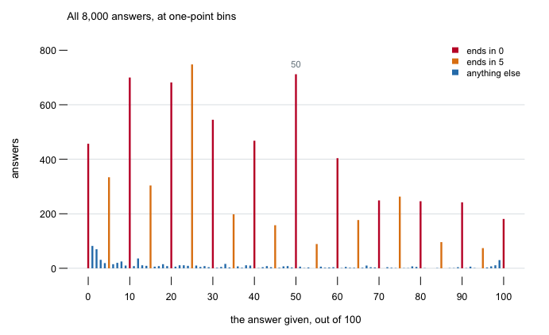

Click an item to see the thousand answers to that question on their own, with the true share marked. Hover for the count at any value.

**Figure 3. Every answer, at one-point bins.** In the browser you can click any single item and see its own thousand answers against its own true share.

**61.1% of the answers end in a zero.** 91.6% end in a zero or a five, and 8.9% of all answers are exactly 50 — what a person types when they do not know and the box will not let them say so. That pile is lumpy and it leans: a few people answering 90 pull the average up and nothing pulls it back.

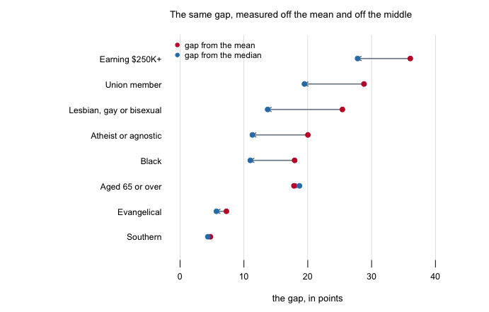

| Group | Really | Mean guess | Middle guess | Gap from the mean | Gap from the middle |
| --- | --- | --- | --- | --- | --- |
| Earning $250K+ | 2.2 | 38.2 | 30 | +36.1 | +27.8 |
| Union member | 10.5 | 39.3 | 30 | +28.8 | +19.5 |
| Lesbian, gay or bisexual | 6.3 | 31.7 | 20 | +25.4 | +13.7 |
| Atheist or agnostic | 8.7 | 28.7 | 20 | +20.0 | +11.3 |
| Black | 24.0 | 41.9 | 35 | +17.9 | +11.0 |
| Aged 65 or over | 21.3 | 39.1 | 40 | +17.8 | +18.7 |
| Evangelical | 34.3 | 41.6 | 40 | +7.3 | +5.7 |
| Southern | 35.6 | 40.4 | 40 | +4.7 | +4.3 |

**Figure 4. The same eight gaps, measured from the average guess and from the middle one.** Measured off the middle, the average gap is 14.0 points rather than 19.8. Neither number is wrong: the average answers *what does the country believe on average*, the middle answers *what does a typical person believe*, and they are 5.8 points apart.

One more compression sits under everything above, and it is the subtitle. The true shares span 33.5 points across the eight groups; the average guesses span 13.2. The guesses do track reality: the correlation between the eight true shares and the eight average guesses — a measure of how closely two lists of numbers rise and fall together, on a scale where 0 is no relation and 1 is a perfect straight line — is 0.633. But they are squeezed into a high band: six of the eight average guesses fall between 38 and 42. Anyone answering near forty about a group really at 2.2% is 36.1 points wrong automatically, so a ranking of the gaps is close to a ranking of the groups from rarest to commonest.

## What this brief cannot tell you

**Why people answer near forty is not settled.** It could be that they picture the party through its stereotypes, which is the study’s argument. It could be that somebody with no information gives a number in the middle of the scale, which would produce the same compression without anyone being misled. This brief can show the pattern; it cannot say what causes it.

**The true shares are estimates too.** Each was computed from a survey rather than counted, so each carries a standard error — the wobble that comes from asking a sample rather than everyone, and the ingredient a margin of error is made from; the widest is Evangelical, at 34.3% — honestly somewhere between 30.9% and 37.7%. Small against a twenty-point gap, but the gap is a distance between two estimates, not between a guess and a fact.

**The panel is not the country.** YouGov recruits volunteers, and the case weight is what stands between that and a national statement. The surveys-source chapter sets out what a sample like this can establish, and the ces-class chapter shows what happens when the weights are turned off.

**Eight groups is a small and chosen list.** The authors picked groups each party is stereotyped around — the right list for their question, and a list built to produce large gaps. A different eight would give different numbers, and the actuals describe the parties as of 2015.

## What you should have learned

- Every one of the eight groups is overestimated, by 19.8 points on average, and the rarest groups are missed the worst.
- People misjudge their own party by 17.7 points and the other party by 24.6 — both sides, in the same direction, which is how polarization can run on wrong facts.
- 61.1% of the answers end in a zero and 8.9% are exactly 50, so the “average belief” is an average of round guesses, and it sits 5.8 points above the middle one.
- A public replication file is not the study: 6 of its columns are undocumented, including the one Figure 2 rests on.

## Extensions

- `items.csv` puts `actual_pct` beside `perceived_pct` for every group asked about. Which group is misjudged by the widest margin, and is it guessed too high or too low?
- `by_party.csv` splits every guess by who is doing the guessing, with the `gap` computed per cell. Do people judge their own party more accurately than the other one? Check every item before you answer.
- `heaping.csv` counts the answers that are multiples of ten, multiples of five, and exactly 50, item by item. Work out which item drew the roundest answers. What does that say about how precise a survey percentage really is?
- `items.csv` gives both a `gap_mean` and a `gap_median` for the same question, and they disagree. Look at `dist.csv` to see why. Which one would you report?
- **Stretch:** put the eight questions to a room of people, after any questions about who they are, and score the room twice — against the true shares, and against the national guesses. Is the room less wrong than the country, or wrong in a different direction?
- **Stretch:** the true shares are a decade old. Recompute one of them from a current survey; the distance between the 2015 figure and today’s is a finding, not a correction.

## Sources

**Data**

- The data is a **YouGov survey of 1,000 American adults, fielded in March 2015** for Douglas J. Ahler and Gaurav Sood. YouGov does not publish it.
- The copy read here is their replication deposit for “The Parties in Our Heads: Misperceptions About Party Composition and Their Consequences,” *The Journal of Politics* 80(3), 2018: 964–981, doi:10.1086/697253, on Harvard Dataverse, doi:10.7910/DVN/CLMQ8E. 26 columns of the study, plus the eight true shares and the published averages. https://doi.org/10.7910/DVN/CLMQ8E
- The true shares in that deposit were computed by the authors from the American National Election Studies, the Current Population Survey (https://www.census.gov/programs-surveys/cps.html) and a Pew Research Center report on religion, its Religious Landscape Study (https://www.pewresearch.org/religion/religious-landscape-study/).
- The averages recomputed here from the 8,000 individual answers reproduce the published ones to five decimal places, which is the check this brief runs before it writes anything else.

**The data itself**

Every figure above is drawn from these tables. They are plain CSV, they open in a spreadsheet, and they are yours to take further.

`answers.csv`, `by_party.csv`, `coverage.csv`, `dist.csv`, `heaping.csv`, `items.csv`, `perception_benchmarks.csv`

Two more files here are not data about the subject at all – they are how this chapter checked its own work: `facts.csv`, the individual numbers the text above quotes, and `checks.csv`, the arithmetic verified before anything was drawn.

Rebuild this data yourself, with an AI assistant

```
I want to rebuild a public dataset from its original source, without any
starting files. Please do the following and show your work.

THE SOURCE. A YouGov survey of 1,000 American adults, fielded in March
2015 for Douglas Ahler and Gaurav Sood. YouGov does not publish it, and
you cannot have it. What you can have is the copy of part of it the two
authors deposited so their results could be checked: the replication
archive for "The Parties in Our Heads: Misperceptions About Party
Composition and Their Consequences", The Journal of Politics 80(3),
2018, on Harvard Dataverse at doi:10.7910/DVN/CLMQ8E. Seventeen files,
all public, no account and no key. You want four of them:

  pcomp_yougov_data   1,000 respondents from a March 2015 YouGov study,
                      one row each, with eight estimates, a case weight
                      and party identification
  fig_1_data_actual   the true share of each group in each party, with a
                      standard error on each
  fig_1_data_perc     the published perceived means, to check yourself
                      against
  codebook            what every column holds

HOW TO DOWNLOAD THEM. List the files with the Dataverse API:
https://dataverse.harvard.edu/api/datasets/:persistentId/?persistentId=doi:10.7910/DVN/CLMQ8E
That returns JSON with a numeric id for each file. Download one with
https://dataverse.harvard.edu/api/access/datafile/ followed by the id.

The catch is silent and it will cost you an afternoon if you miss it.
That address answers 303, not 200, and hands back a redirect to
storage. A client that does not follow redirects writes a zero-byte
file and reports success. Follow redirects, then check the file size
before you parse anything.

WHAT TO BUILD.
1. One row per person per item: 8,000 answers, each with the case
   weight and the group and party it belongs to.
2. The weighted mean of each item, which is what the paper published.
   Weight, or you will be close and wrong.
3. The median of each item beside that mean, and the gap from the true
   share computed both ways.
4. How round the answers are: the share ending in a zero, the share
   ending in a zero or a five, and the share that are exactly 50.
5. The eight items split by the respondent's own party, from pid7, so
   you can compare what people say about their own party against what
   they say about the other one. Note that pid7 is in the file and not
   in the codebook; set the two against each other and you will find
   three columns described and absent, and six present and undescribed.

CHECK YOUR WORK. The copies this book used were downloaded in August 2026.
If your rebuild matches them, you should find:
- 1,000 respondents and 8,000 answers, every one between 0 and 100
- your weighted means landing on the published ones to five decimal
  places; the worst of the eight items here first differs from the
  published figure in the sixth decimal place
- an average gap of 19.8 points measured from the mean and 14.0
  measured from the median
- 61.1% of answers ending in a zero, 91.6% ending in a zero or a five,
  and 8.9% of them exactly 50
- the largest single gap on the Republican $250,000-and-over item: a
  true share of 2.19% against a mean guess of 38.25%
- people overestimating their own party by 17.7 points and the other
  party by 24.6, counting leaners as partisans
This archive was deposited in 2017 and has not changed since, so a
number that does not match is yours rather than theirs.
```

[^1]: Douglas J. Ahler and Gaurav Sood, “The Parties in Our Heads: Misperceptions About Party Composition and Their Consequences,” *Journal of Politics* 80, no. 3 (2018): 964–981, doi:10.1086/697253.